# Week 5 Coding: T-tests, Cohen’s d, one-way ANOVA

Travis Christy

11/14/2020

# Part 1. T-tests

Mass comparison: male & female chinstrap penguins

First we are doing some exploring

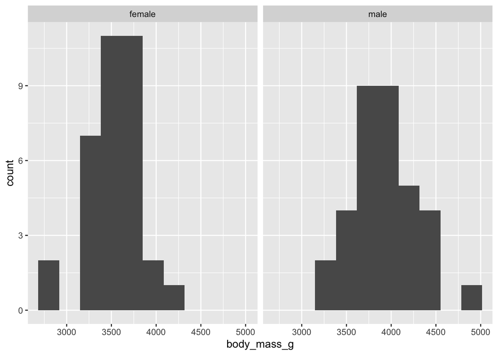

```r
chinstraps <- penguins %>%
  filter(species == "Chinstrap")

# Histograms
ggplot(data = chinstraps, aes(x = body_mass_g)) +
  geom_histogram(bins = 10) +
  facet_wrap(~sex)
```

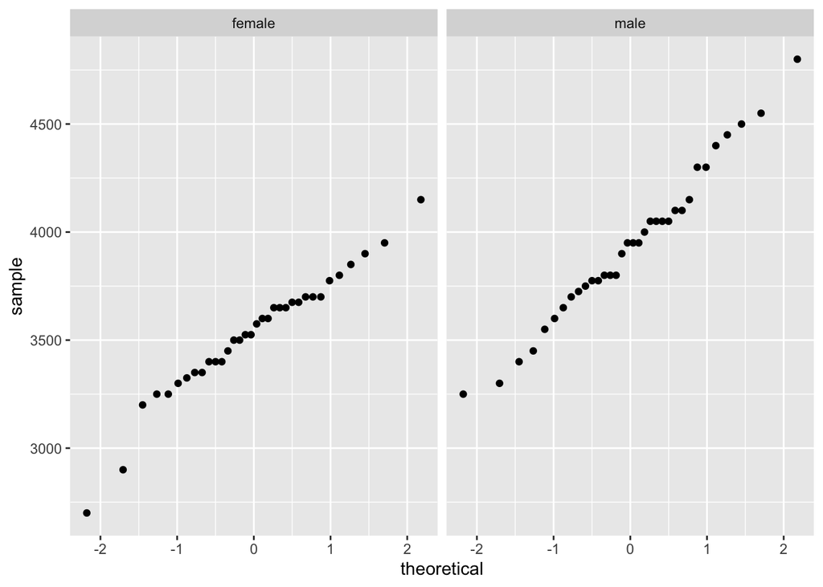

```r
# Quantile Quantile Plots
ggplot(data = chinstraps, aes(sample = body_mass_g)) +
  geom_qq() +
  facet_wrap(~sex)
```

```r
# Get descriptive statistics with summary table
chinstraps %>%
  group_by(sex) %>%
  summarise(
    mean_mass = mean(body_mass_g),
    median_mass = median(body_mass_g),
    sd_mass = sd(body_mass_g),
    sample_size = n()
  )
```

```
## # A tibble: 2 x 5
##   sex    mean_mass median_mass sd_mass sample_size
##   <fct>      <dbl>       <dbl>   <dbl>       <int>
## 1 female     3527.        3550    285.          34
## 2 male       3939.        3950    362.          34
```

Re: Histogram - The distribution overall looks somewhat normal (bell shaped)

Re: QQ Plot - Linear distribution means they are close to normal (this is what very close to normal looks like)

## Get Vectors of body_mass_g for female and male chinstrap penguins separately

```r
chinstraps_f <- chinstraps %>%
  filter(sex == "female") %>%
  pull(body_mass_g)

chinstraps_m <- chinstraps %>%
  filter(sex == "male") %>%
  pull(body_mass_g)
```

## T-Tests, a couple different ways

Is there a significant difference in body mass between male and female chinstrap penguins? (Use two-sided t-test)

```r
chinstrap_ttest <- t.test(chinstraps_f, chinstraps_m)
chinstrap_ttest
```

```
##
##  Welch Two Sample t-test
##
## data:  chinstraps_f and chinstraps_m
## t = -5.2077, df = 62.575, p-value = 2.264e-06
## alternative hypothesis: true difference in means is not equal to 0
## 95 percent confidence interval:
##  -569.7903 -253.7391
## sample estimates:
## mean of x mean of y
##  3527.206  3938.971
```

```r
cohen.d(chinstraps_m, chinstraps_f)
```

```
##
## Cohen's d
##
## d estimate: 1.263061 (large)
## 95 percent confidence interval:
##     lower     upper
## 0.7327341 1.7933879
```

You can see from the t-test the P-value allows us to reject null hypothesis You can see from the cohen’s d test, that there is a large effect size

Are male chinstrap penguins significantly larger (in body mass) than female chinstrap penguins? (use one-sided t-test)

```r
t.test(chinstraps_m, chinstraps_f, alternative = "greater")
```

```
##
##  Welch Two Sample t-test
##
## data:  chinstraps_m and chinstraps_f
## t = 5.2077, df = 62.575, p-value = 1.132e-06
## alternative hypothesis: true difference in means is greater than 0
## 95 percent confidence interval:
##  279.7552      Inf
## sample estimates:
## mean of x mean of y
##  3938.971  3527.206
```

## One way ANOVA

Comparing means across more than 2 groups. One-way means exploring a single factor.

### Data Exploration:

#### 1. Table of counts by species and sex

```r
penguins_counts <- penguins %>%
  count(species, sex)
penguins_counts
```

```
## # A tibble: 8 x 3
##   species   sex        n
##   <fct>     <fct>  <int>
## 1 Adelie    female    73
## 2 Adelie    male      73
## 3 Adelie    <NA>       6
## 4 Chinstrap female    34
## 5 Chinstrap male      34
## 6 Gentoo    female    58
## 7 Gentoo    male      61
## 8 Gentoo    <NA>       5
```

#### 2. Create subset of only female penguins & look at distributions

Histograms: A few different styles

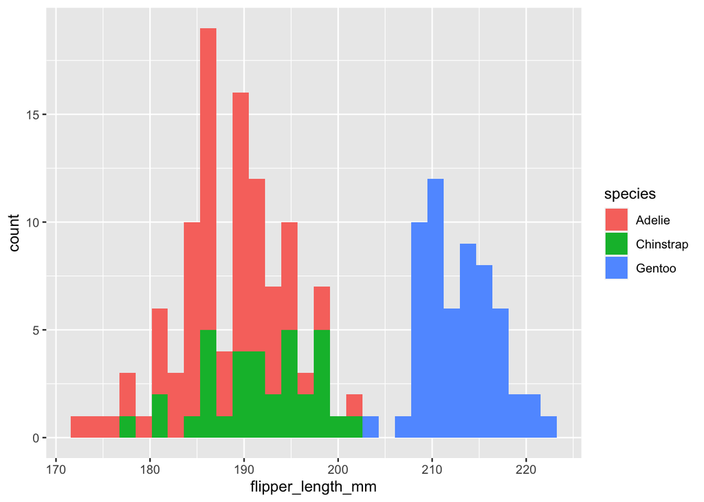

```r
penguin_f <- penguins %>%
  filter(sex == "female")

ggplot(data = penguin_f, aes(x = flipper_length_mm)) +
  geom_histogram(aes(fill = species))
```

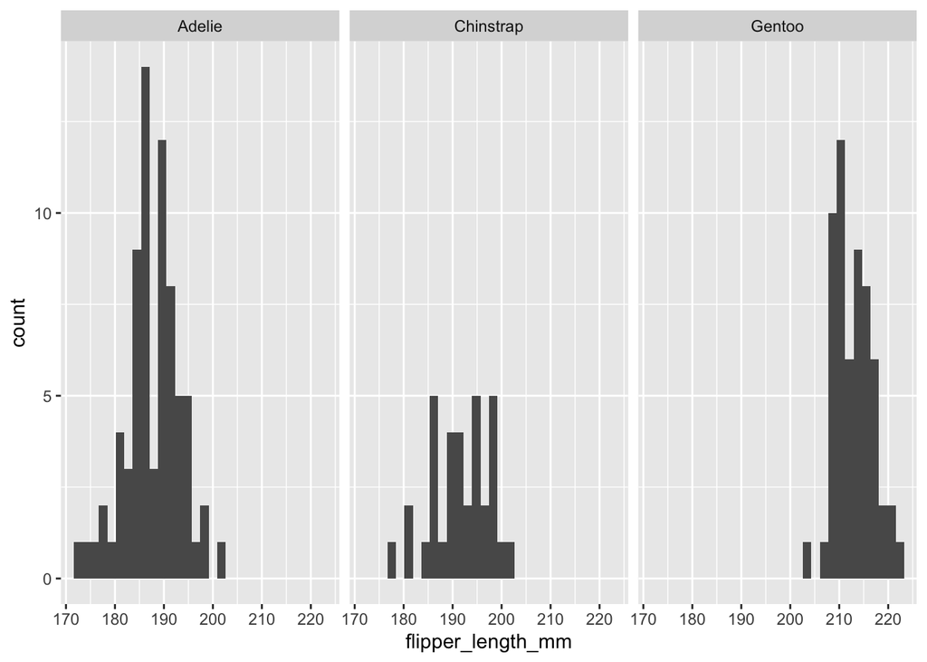

```r
ggplot(data = penguin_f, aes(x = flipper_length_mm)) +
  geom_histogram() +
  facet_wrap(~species)
```

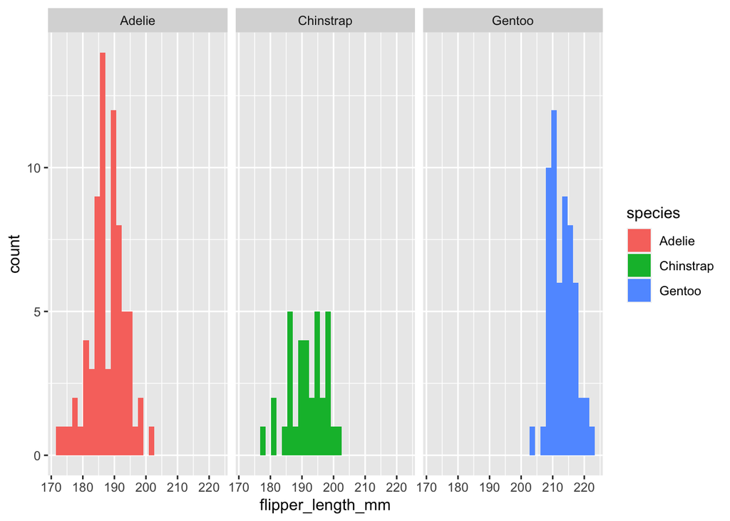

```r
ggplot(data = penguin_f, aes(x = flipper_length_mm)) +
  geom_histogram(aes(fill = species)) +
  facet_wrap(~species) # to see distributions across groups
```

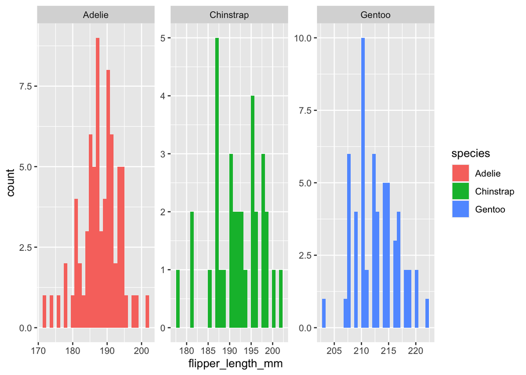

```r
ggplot(data = penguin_f, aes(x = flipper_length_mm)) +
  geom_histogram(aes(fill = species)) +
  facet_wrap(~species, scales = "free") # to see distributions within groups
```

QQ Plots

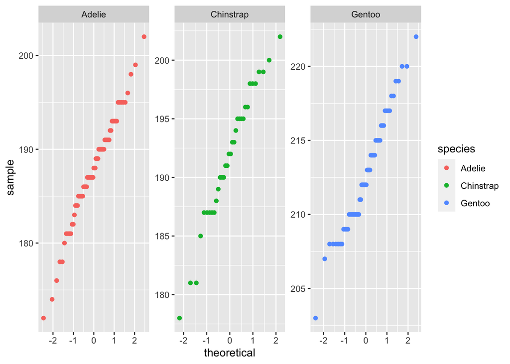

```r
ggplot(data = penguin_f, aes(sample = flipper_length_mm)) +
  geom_qq(aes(color = species)) +
  facet_wrap(~species, scales = "free")
```

```r
# the linear distribution is pretty close to what is possible in real-life data, close to the best you can hope for
```

### Summary Statistics

```r
penguin_f_summary <- penguin_f %>%
  group_by(species) %>%
  summarise(
    mean_flipper_length = mean(flipper_length_mm),
    sd_flipper_length = sd(flipper_length_mm),
    sample_size = n(),
    se_flipper_length = sd(flipper_length_mm)/sqrt(n()),
    var_flipper_length = var(flipper_length_mm)
  )
penguin_f_summary
```

```
## # A tibble: 3 x 6
##   species mean_flipper_le… sd_flipper_leng… sample_size se_flipper_leng…
##   <fct>              <dbl>            <dbl>       <int>            <dbl>
## 1 Adelie              188.             5.60          73            0.655
## 2 Chinst…             192.             5.75          34            0.987
## 3 Gentoo              213.             3.90          58            0.512
## # … with 1 more variable: var_flipper_length <dbl>
```

Remember the ANOVA test is robust to violations of the normality assumptions and the equal variance assumption. You have to look at the data and then also run the Levene’s test for equal variance. Generally, if the largest sample variance is <4x the smallest sample variance, the variances are close enough. Here, the largest sample variance is Chinstrap (33.1) and the smallest sample variance is Gentoo (15.2) which is only 2X less than the largest (within the <4x guideline).

#### Levene’s test for equal variance

Use with caution, has same problem as other hypothesis tests do – larger sample sizes are more likely to show significance. If you get a result that shows significant difference, then check back to make sure the variance falls within the 4:1 guidelines.

```r
leveneTest(flipper_length_mm ~ species, data = penguin_f)
```

```
## Levene's Test for Homogeneity of Variance (center = median)
##        Df F value  Pr(>F)
## group   2  2.9012 0.05782 .
##       162
## ---
## Signif. codes:  0 '***' 0.001 '**' 0.01 '*' 0.05 '.' 0.1 ' ' 1
```

.05782 is above the .05 threshold, yes we can assume equal variance.

### Beeswarm plot with mean +/- 1 standard deviation (sd)

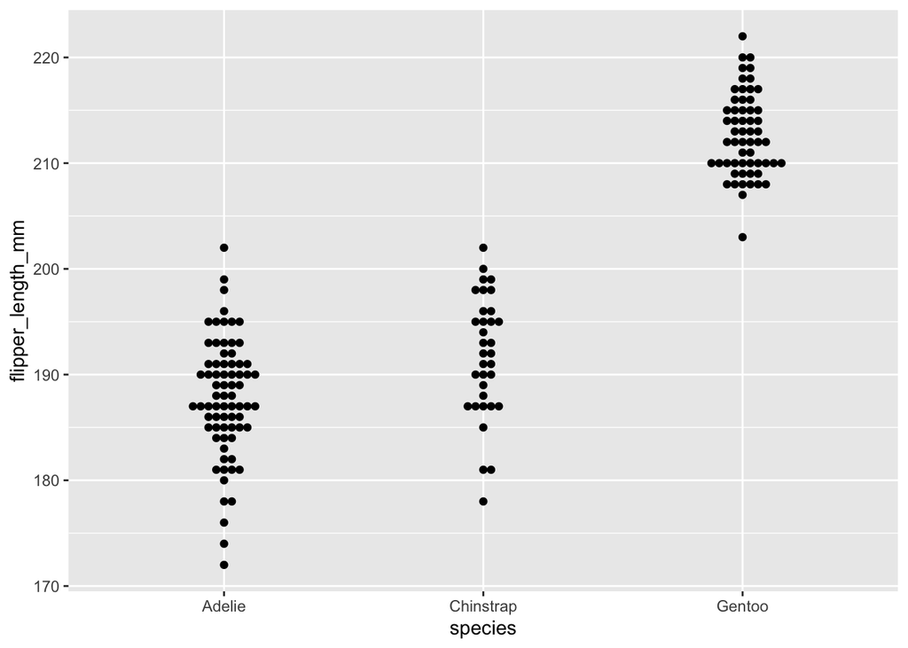

```r
ggplot()+
  geom_beeswarm(data = penguin_f, aes(x = species, y = flipper_length_mm))
```

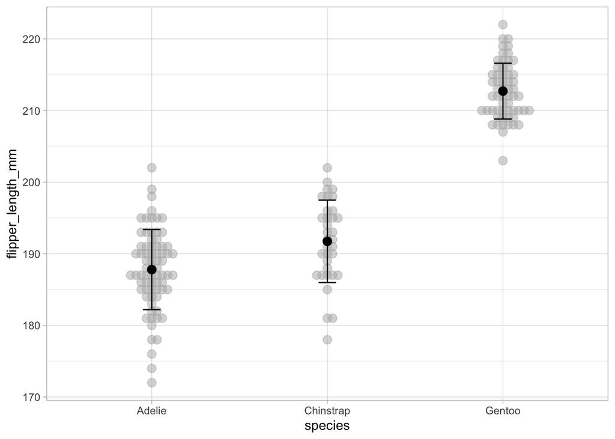

```r
ggplot()+
  geom_beeswarm(data = penguin_f,
                aes(x = species, y = flipper_length_mm),
                color = "gray70",
                size = 3,
                alpha = 0.5) +
  geom_point(data = penguin_f_summary, aes(x = species, y = mean_flipper_length),
             size = 3) +
  geom_errorbar(data = penguin_f_summary,
                aes(x = species,
                    ymax = mean_flipper_length + sd_flipper_length,
                    ymin = mean_flipper_length - sd_flipper_length),
                width = 0.1) +
  theme_light()
```

We have decided that a means comparison via ANOVA is appropriate from all the above data viz

### One-way ANOVA

```r
penguin_aov <- aov(flipper_length_mm ~ species, data = penguin_f)
summary(penguin_aov)
```

```
##              Df Sum Sq Mean Sq F value Pr(>F)
## species       2  21416   10708   411.8 <2e-16 ***
## Residuals   162   4213      26
## ---
## Signif. codes:  0 '***' 0.001 '**' 0.01 '*' 0.05 '.' 0.1 ' ' 1
```

You can see with the very high F value that there is high variance across the groups compared to the variance between groups. The p-value is extremely low and means we can reject the null hypothesis that the groups were actually drawn from populations with the same mean values. Now, we use a post-hoc test TukeyHSD to find the adjusted significant difference between each pair of groups.

```r
TukeyHSD(penguin_aov)
```

```
##   Tukey multiple comparisons of means
##     95% family-wise confidence level
##
## Fit: aov(formula = flipper_length_mm ~ species, data = penguin_f)
##
## $species
##                       diff       lwr       upr     p adj
## Chinstrap-Adelie  3.940774  1.436275  6.445272 0.0007922
## Gentoo-Adelie    24.912376 22.790647 27.034105 0.0000000
## Gentoo-Chinstrap 20.971602 18.366227 23.576977 0.0000000
```

If you have very different sample sizes, variance, and overall unbalanced design, you would use a type III ANOVA with the car package:

First create linear model to find linear relationship

```r
penguin_lm <- lm(flipper_length_mm ~ species, data = penguin_f)
pengiun_aov_t3 <- Anova(penguin_lm, type = "III")
```

```r
pengiun_aov_t3
```

```
## Anova Table (Type III tests)
##
## Response: flipper_length_mm
##              Sum Sq  Df  F value    Pr(>F)
## (Intercept) 2574475   1 99005.28 < 2.2e-16 ***
## species       21416   2   411.79 < 2.2e-16 ***
## Residuals      4213 162
## ---
## Signif. codes:  0 '***' 0.001 '**' 0.01 '*' 0.05 '.' 0.1 ' ' 1
```